# Introduction

2021-09-30

## Programming Language

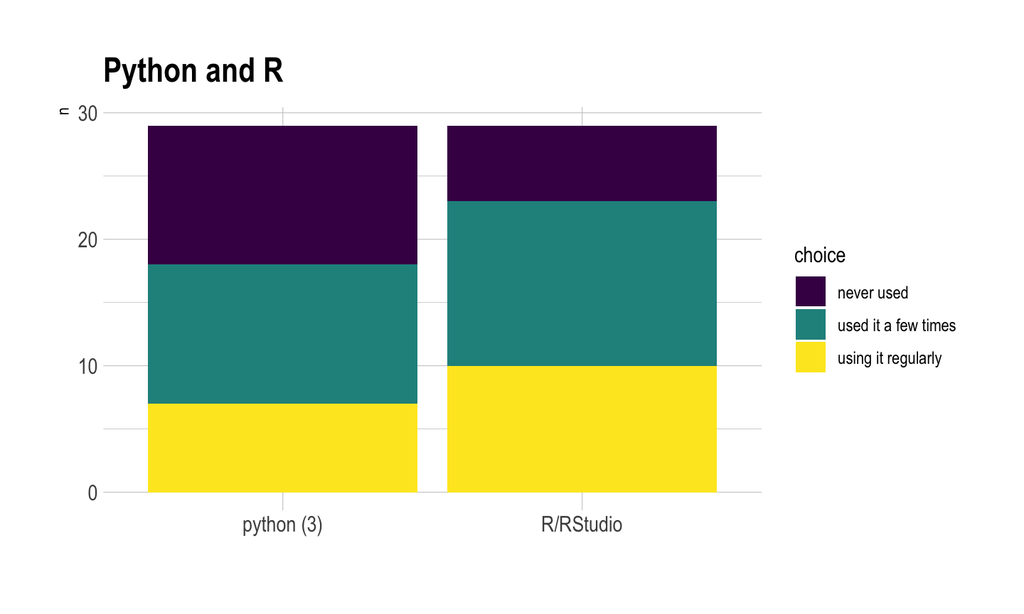

## Where to code?

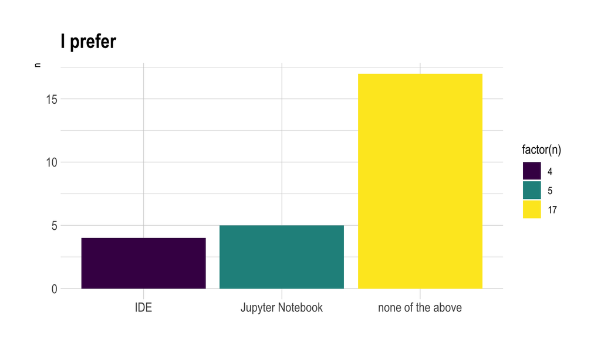

## Where to find code?

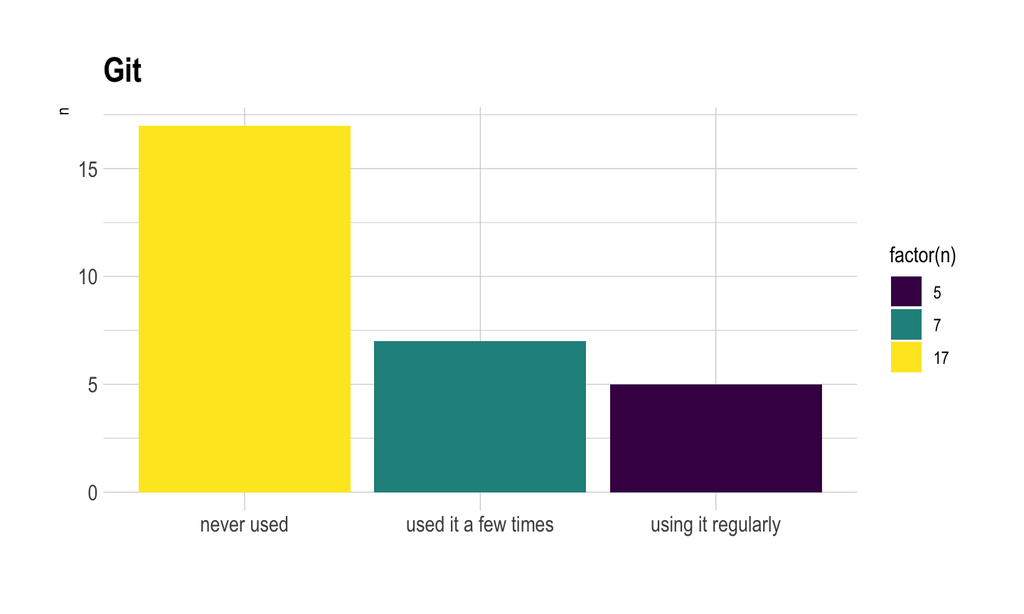

## How to install?

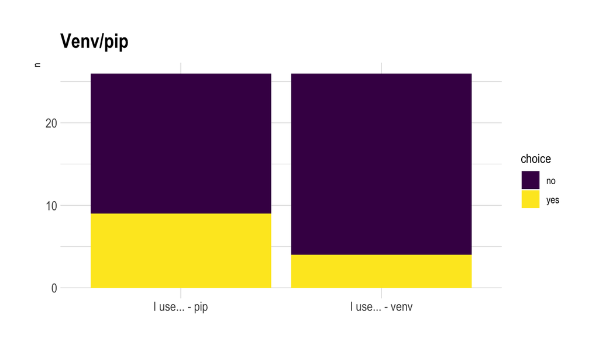

## Session 1

## Political Speech

📈 [Plenarprotokolle Deutscher Bundestag](https://www.bundestag.de/dokumente/protokolle/plenarprotokolle), [New York Times front pages](http://www.amber-boydstun.com/supplementary-information-for-making-the-news.html), [Manifestos Project Database](https://manifestoproject.wzb.eu)

- Programming language: R (mainly [quanteda](https://quanteda.io))
- Methods
  - Descriptive Methods 👨‍🏫 12’, 👨‍💻 12’
    - Corpus, types, tokens, sentences
    - Readability scores ([overview](https://quanteda.io/reference/textstat_readability.html), [Flesch (1948)](https://psycnet.apa.org/record/1949-01274-001))
    - Dfm
    - [Comparing texts](https://quanteda.io/reference/textstat_simil.html) (e.g. via cosine similarity)
    - Keywords in context
  - Classification 👩‍🏫 12’, 👨‍💻 12’
    - [Train/Test split](https://towardsdatascience.com/train-validation-and-test-sets-72cb40cba9e7)
    - Naive Bayes Classifier ([Schütze et al. (2008), ch 13](https://nlp.stanford.edu/IR-book/pdf/irbookonlinereading.pdf))
    - Importance of sampling
    - Evaluation metrics
- Scaling models 👩‍🏫 12’, 👩‍💻 12’
  - Wordscore ([Laver et al. (2003)](https://www.cambridge.org/core/journals/american-political-science-review/article/extracting-policy-positions-from-political-texts-using-words-as-data/4F4676E80A79E01EAAB88EF3F2D1B733))
  - Wordfish ([Slapin (2008)](https://onlinelibrary.wiley.com/doi/abs/10.1111/j.1540-5907.2008.00338.x))
  - Wordshoal ([Lauderdale (2016)](https://www.cambridge.org/core/journals/political-analysis/article/measuring-political-positions-from-legislative-speech/35D8B53C4B7367185325C25BBE5F42B4))
- Measuring divisiveness in political speech ([Ash (2017)](https://www.journals.uchicago.edu/doi/full/10.1086/692587?af=R&mobileUi=0)) 👨‍🏫 12’, 👩‍💻 12’

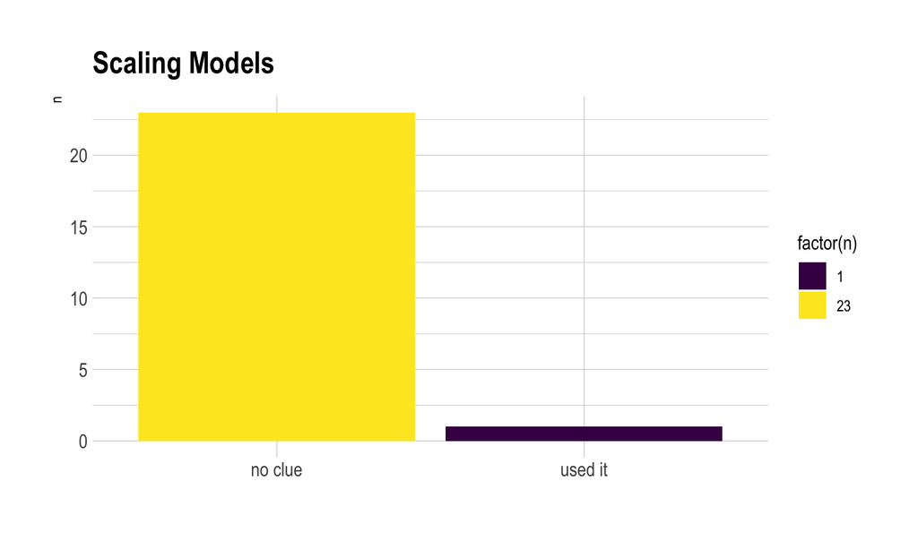

## Session 2

## Tax Risk Management (I)

📈 Tax reports from German companies listed in the STOXX Europe 600.

- Programming language: Python (mostly [scikit-learn](https://scikit-learn.org/stable/))
- Methods
  - 👨‍🏫 10’, 👩‍💻 10’
    - Text preprocessing ([Stemming, Lemmatization](https://nlp.stanford.edu/IR-book/html/htmledition/stemming-and-lemmatization-1.html))
    - Train/Test split
    - [Feature extraction](https://scikit-learn.org/stable/modules/feature_extraction.html)
- Classification 👩‍🏫 10’, 👩‍💻 10’
  - [Multinomial Bayes](https://scikit-learn.org/stable/modules/naive_bayes.html#multinomial-naive-bayes)
  - [Passive Aggressive Algorithms](https://scikit-learn.org/stable/modules/linear_model.html#passive-aggressive-algorithms)
  - [Support Vector Machines](https://scikit-learn.org/stable/modules/svm.html#classification)
  - Gazetteer/Entity Dictionary

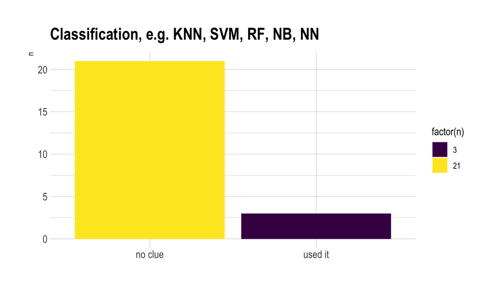

## Predicting (Non) Compliance

📈 chat data from a [laboratory experiment](https://www.socialscienceregistry.org/trials/5049)

- Programming language: Python (mostly [scikit-learn](https://scikit-learn.org/stable/))
- Presentation: Chapter 2 from my [dissertation](https://kups.ub.uni-koeln.de/12231/) 👩‍🏫 15’

## Session 3

## Predicting (Non) Compliance—Continued

- Methods
  - Feature engineering 👨‍🏫 10’, 👩‍💻 10’
    - Input: concatenating chat on different levels (individuals, versus groups)
    - Output: applying different thresholds to binarize the continuous dependent variable
    - Sampling ([oversampling](https://imbalanced-learn.org/stable/over_sampling.html#random-over-sampler))
    - [Stratified Group Shuffle Split](https://stackoverflow.com/questions/56872664/complex-dataset-split-stratifiedgroupshufflesplit)
  - Embeddings 👩‍🏫 15’, 👨‍💻 15’
    - Word2Vec ([Mikolov (2013)](https://arxiv.org/abs/1301.3781))
    - GloVe ([Pennington (2014)](https://aclanthology.org/D14-1162.pdf))
    - fastText ([Joulin (2016)](https://arxiv.org/pdf/1607.01759.pdf?fbclid=IwAR1wttEXho2gqk3BasKDuncgftN5I5lmH2TbIgvGuHxfutM3IavbateHH9A))
    - Doc2Vec (PV-DM) ([Le (2014)](http://proceedings.mlr.press/v32/le14.html))
- Classification 👨‍🏫 15’, 👨‍💻 15’
  - [Tuning Hyperparametes](https://scikit-learn.org/stable/modules/grid_search.html#grid-search)
  - [Cross-validation](https://scikit-learn.org/stable/modules/cross_validation.html#cross-validation)
  - Models
    - [Linear classifier (log loss) with SGD training](https://scikit-learn.org/stable/modules/sgd.html#sgd)
    - [KNN](https://scikit-learn.org/stable/modules/neighbors.html#classification)
- [ensemble methods](https://scikit-learn.org/stable/modules/ensemble.html)
  - [Random Forest](https://scikit-learn.org/stable/modules/generated/sklearn.ensemble.RandomForestClassifier.html)
  - [bagging classifier](https://scikit-learn.org/stable/modules/generated/sklearn.ensemble.BaggingClassifier.html)
  - [stacked generalization](https://scikit-learn.org/stable/modules/ensemble.html#stacked-generalization)

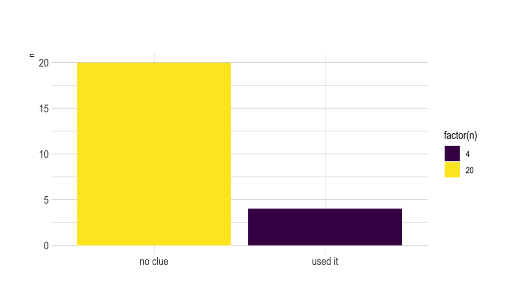

## Session 4

## Predicting (Non) Compliance—Continued

- Parallelization 👩‍💻 5’
- Scoring 👩‍🏫 10’, 👨‍💻 10’
  - [Accuracy, precision, recall, f1-score, AUC](https://scikit-learn.org/stable/modules/model_evaluation.html#precision-recall-f-measure-metrics)
  - Evaluate within and across datasets ([Straube (2014)](https://www.frontiersin.org/articles/10.3389/fncom.2014.00043/full))

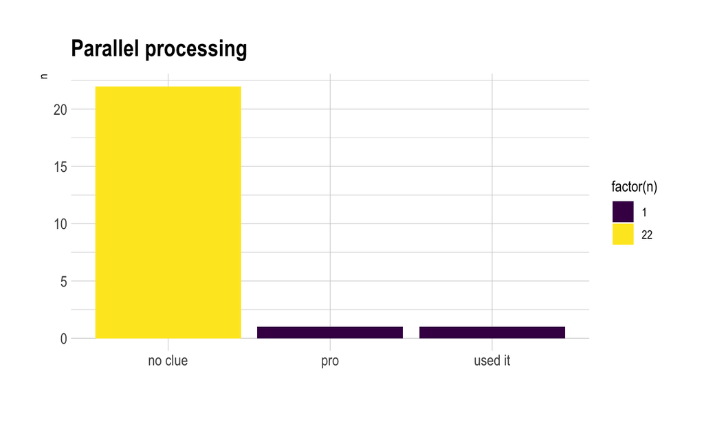

## Ideological Direction in Judicial Opinion

📈 US Circuit Court judicial decisions

- Programming language: Python (mostly [scikit-learn](https://scikit-learn.org/stable/))
- Presentation: [Hausladen et al. 2020](https://www.sciencedirect.com/science/article/pii/S0144818819303667) 👩‍🏫 15’
- Methods
  - Feature engineering: exploiting the specific structure of judicial texts (citations/quotations)
  - [Probability calibration](https://scikit-learn.org/stable/modules/calibration.html#) 👩‍🏫 5’, 👩‍💻 10’

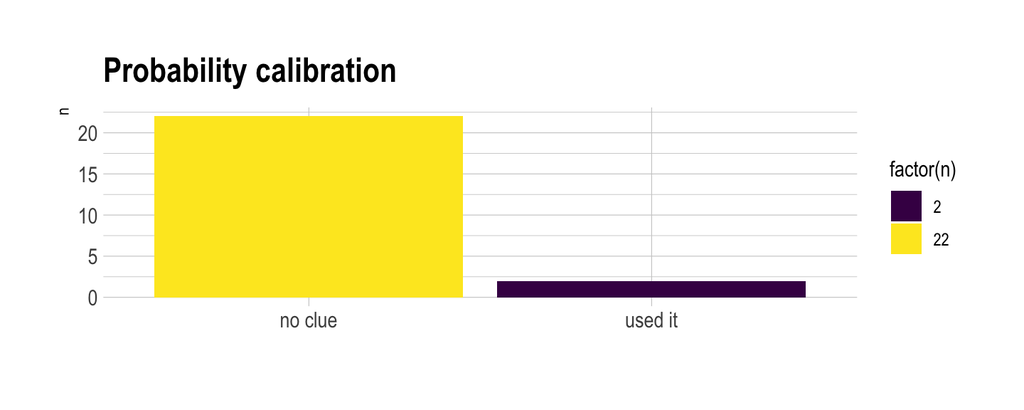

## Further Techniques

- Sentiment Analysis with LSTM 👩‍🏫 7’, 👩‍💻 7’
- RCNN ([Lai et al. (2015)](https://www.aaai.org/ocs/index.php/AAAI/AAAI15/paper/viewPaper/9745)) 👩‍🏫 7’, 👩‍💻 7’

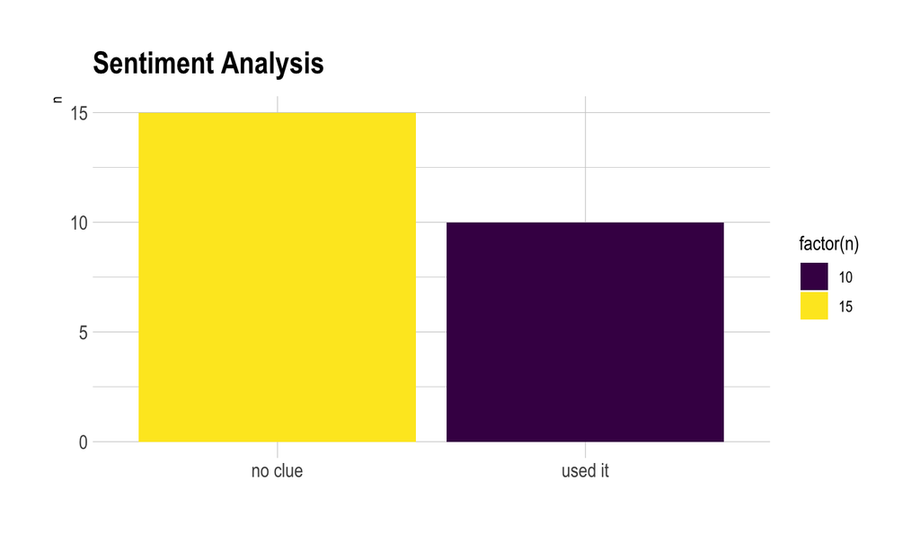

## Session 5

## Charting the Type Space

📈 simulated decision data from a multi-stage public good game

- Programming language: R (mostly [dtw clust](https://cran.r-project.org/web/packages/dtwclust/dtwclust.pdf))
- Presentation: Chapter 3 of my [dissertation](https://kups.ub.uni-koeln.de/12231/) 👩‍🏫 15’
- Methods ([Sarda-Espinosa (2017)](https://mran.microsoft.com/snapshot/2018-07-24/web/packages/dtwclust/vignettes/dtwclust.pdf)) 👩‍🏫 20’, 👨‍💻 20’
  - distance measures (dtw, sdtw)
  - prototypes (dba)
  - clustering algorithms (hierarchical, partitional)
  - cluster evaluation (e.g. majority vote of different indices)

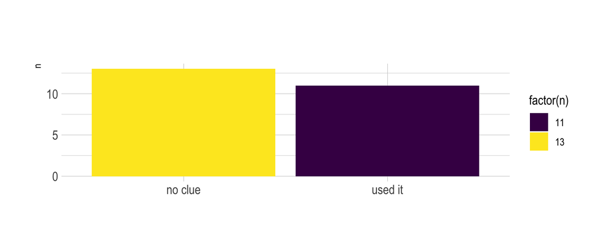

## Tax Risk Management (II)

📈 Tax reports from German companies listed in the STOXX Europe 600.

- Programming language: Python (mostly [scikit-learn](https://scikit-learn.org/stable/))
- Methods 👩‍🏫 10’, 👨‍💻 10’
  - Clustering ([K-means](https://scikit-learn.org/stable/modules/clustering.html#k-means))
  - Visualize high-dimensional data ([t-SNE](https://scikit-learn.org/stable/modules/manifold.html#t-sne))
  - Topic Models ([NFM](https://scikit-learn.org/stable/modules/decomposition.html#non-negative-matrix-factorization-nmf-or-nnmf), [LDA](https://scikit-learn.org/stable/modules/decomposition.html#latent-dirichlet-allocation-lda))

## Let’s compete for Swiss chocolate!

After every session, it’s quiz time. 🦊